# R exercise: phenotype data proprocessing

Haoyue Shuai

Oct. 8th, 2020

## Instruction

This exercise was adapted by Haoyue Shuai from one of her analysis on phenotype data in preparation for genetic association studies. Don’t panic if you’re just starting to learn R. The exercise does not involve writing serious software programs in R, but rather to execute some interactive and intuitive commands to get some preliminary phenotype data analysis done. There will be some questions throughout that you can answer using your own words (and some data science intuition) with a few sentences. Some of them involve writing additional codes but you can mostly find and modify codes we provide as examples to address the questions. You do not have to answer all the questions but we strongly encourage you to make an attempt.

If you use Jupyter Notebook, please show your answers, codes and plots in the notebook when needed. If you work directly with this Rmd file and use R studio, please convert it into HTML format for us to review (simply by clicking the knit icon in your Rstudio toolbar). Please push the Jupyter Notebook or the Rmd + HTML files to your fork repository on github, then send us a link to it at wang.gao@columbia.edu. Please don’t hesitate to contact us for any scientific or technical blockers, if you cannot find a solution yourself online.

### Dataset

The data-set can be found as `data_cleaned.csv`.

## Genetic association study

We perform genetic association studies to identify genetic factors (variants) that may be involved in a complex trait (tinnitus, asthma, etc) etiology. In brief, genetic association studies compare and identify difference in genetic data of individuals with disease (cases) to those without (controls). We report genetic variants that are observed more frequently in cases than in controls.

In order to perform genetic association studies, we need phenotype data and genotype data from individuals we collect.

- Phenotype and covariate data: age, sex, height, weight, condition for that trait (tinnitus in the example below case), etc.
- Genotype data: You can roughly understand it as a sequence of the bases in DNA molecules, A/T/C/G, for all chromosomes in human genome.

### Disease phenotype data

We use a toy data-set extracted from the UK Biobank project.

**Load the data**

Load `UKB_Phenotype/data_cleaned.csv`. Note, you only need to complete the codes when seeing `YOUR CODE`. Please execute other existing codes as is.

```r
# you need to put the data-set in the same folder
# where this .rmd file sits,
# which is here:
getwd()
sub_UKBB<-read.csv("data_cleaned.csv")
```

```
## [1] "/Users/adityakankariya/lab_tasks"
```

**Exploratory data analysis (EDA) of the data**

```r
dim(sub_UKBB) # This data covering 144756 participants and 11 variables of them (IID, FID, etc)
```

```
## [1] 144756     11
```

```r
colnames(sub_UKBB) # 11 variables
```

```
##  [1] "IID"         "FID"         "f.4803.0.0"  "f.4803.1.0"  "f.4803.2.0"
##  [6] "f.4803.3.0"  "f.22001.0.0" "f.21003.0.0" "f.21003.1.0" "f.21003.2.0"
## [11] "f.21003.3.0"
```

```r
summary(sub_UKBB)
```

```
##       IID               FID           f.4803.0.0         f.4803.1.0
##  Min.   :1000046   Min.   :1000046   Length:144756      Length:144756
##  1st Qu.:2267981   1st Qu.:2267981   Class :character   Class :character
##  Median :3527260   Median :3527260   Mode  :character   Mode  :character
##  Mean   :3521488   Mean   :3521488
##  3rd Qu.:4779335   3rd Qu.:4779335
##  Max.   :6025411   Max.   :6025411
##
##   f.4803.2.0         f.4803.3.0        f.22001.0.0         f.21003.0.0
##  Length:144756      Length:144756      Length:144756      Min.   :40.00
##  Class :character   Class :character   Class :character   1st Qu.:51.00
##  Mode  :character   Mode  :character   Mode  :character   Median :58.00
##                                                           Mean   :56.98
##                                                           3rd Qu.:63.00
##                                                           Max.   :73.00
##
##   f.21003.1.0      f.21003.2.0      f.21003.3.0
##  Min.   :43.00    Min.   :45.00    Min.   :50.00
##  1st Qu.:57.00    1st Qu.:58.00    1st Qu.:59.00
##  Median :63.00    Median :65.00    Median :66.00
##  Mean   :61.69    Mean   :64.36    Mean   :65.12
##  3rd Qu.:67.00    3rd Qu.:70.00    3rd Qu.:71.00
##  Max.   :79.00    Max.   :82.00    Max.   :82.00
##  NA's   :130131   NA's   :110381   NA's   :142607
```

```r
head(sub_UKBB) # show part of the data
```

```
##       IID     FID                             f.4803.0.0 f.4803.1.0 f.4803.2.0
## 1 1000046 1000046                                   <NA>       <NA>  No, never
## 2 1000063 1000063                              No, never       <NA>       <NA>
## 3 1000078 1000078                                   <NA>  No, never  No, never
## 4 1000105 1000105 Yes, but not now, but have in the past       <NA>       <NA>
## 5 1000112 1000112                                   <NA>       <NA>  No, never
## 6 1000141 1000141                              No, never       <NA>       <NA>
##   f.4803.3.0 f.22001.0.0 f.21003.0.0 f.21003.1.0 f.21003.2.0 f.21003.3.0
## 1       <NA>      Female          62          NA          73          NA
## 2       <NA>        Male          43          NA          NA          NA
## 3       <NA>      Female          52          57          60          NA
## 4       <NA>      Female          54          NA          NA          NA
## 5       <NA>        Male          58          NA          68          NA
## 6       <NA>      Female          49          NA          NA          NA
```

**Q1:** How many females and males are there in this data? Please show your code below how these numbers are computed.

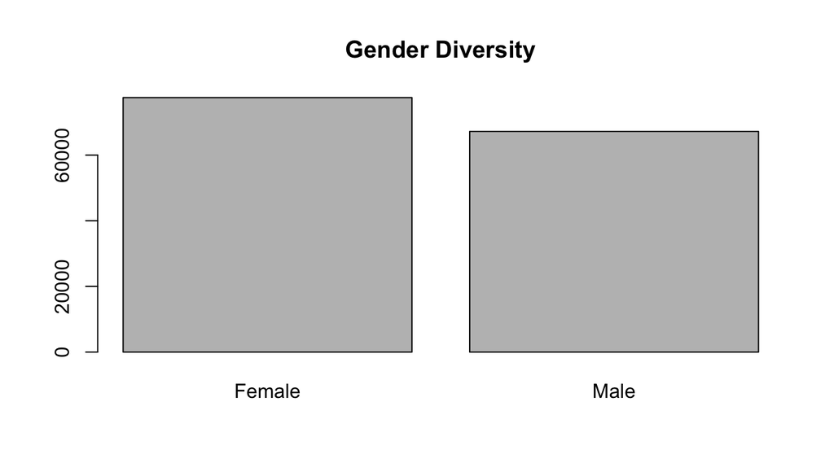

```
##
## Female   Male
##  77535  67221
```

```r
Gender <-table(sub_UKBB$f.22001.0.0)
Gender
barplot(Gender,main="Gender Diversity")
```

**Q2:** Can you tell what kind of trait it is for tinnitus? A.Binary trait. B. Continuous trait.

**Answer** In general conditions, gender is considered as a binary trait. Because here only there are two values male or female.

**Q3:** Recode f.4803

Field 4803 (f.4803) is the answers from participants for ACE touchscreen question “Do you get or have you had noises (such as ringing or buzzing) in your head or in one or both ears that lasts for more than five minutes at a time?”

These fields contains answers to the questions in their first, 2nd, 3rd and 4th hospital visit: f.4803.0.0, f.4803.1.0, f.4803.2.0, f.4803.3.0.

```r
# Recode function:
recode<-function(df,column_name){
  new_names<-c()
  for (i in column_name){
    new_column_name<-paste0(i,"_recode")
    new_names<-c(new_names,new_column_name)
    df[,new_column_name] <- revalue(df[,i], c("No, never"= 0,
                                            "Yes, but not now, but have in the past"= 1,
                                            "Yes, now some of the time"= 1,
                                            "Yes, now a lot of the time"= 1,
                                            "Yes, now most or all of the time"= 1,
                                            "Prefer not to answer"= NA,
                                            "Do not know"= NA ))
  }
  return (list(df=df,new_column_names=new_names))
}

# columns needs to be recoded:
column_name<-c("f.4803.0.0","f.4803.1.0","f.4803.2.0","f.4803.3.0")

# get a new data.frame with recoded columns added:
df_recode<-recode(df=sub_UKBB,column_name)$df

# get names of recoded columns:
new_column_names<-recode(df=sub_UKBB,column_name)$new_column_names

# show recode summary:
for (i in new_column_names)
{cat(i,"summary:");print(table(df_recode[,i]));cat("\n")}
```

```
## f.4803.0.0_recode summary:
##     0     1
## 80805 31685
##
## f.4803.1.0_recode summary:
##     0     1
## 10282  4214
##
## f.4803.2.0_recode summary:
##     0     1
## 22583 11405
##
## f.4803.3.0_recode summary:
##    0    1
## 1451  691
```

What do you think has been achieved by recoding these fields?

**Answer** For statistical analysis, we cant use the strings as input. So we need to code the responses into valid numbers. So we have recorded the responses into the numerical values. Here we replaced “No” by using the value “0”. Similarly the values like “Yes, but not now, but have in the past”, “Yes, now some of the time”, “Yes, now a lot of the time”= 1, “Yes, now most or all of the time” are replaced by value “1”. And the values like “Prefer not to answer”, “Do not know” are replaced by the value “NA”.

**Q4:** Define case and control status of tinnitus for each participant in the study:

```r
data_sub <- df_recode[,new_column_names]
# Function to define cases
f<-function(x){
  visit<-c()
  for (i in 1:4){
    if (!is.na(x[i]))
    {visit<-c(visit,x[i])}
  }
  if ("1" %in% visit){result= TRUE}
  else{result=FALSE}
  return (result)
}
# Apply the above function
df_recode$cases<-apply(data_sub, 1, f)
head(df_recode,10)
```

```
##        IID     FID                             f.4803.0.0 f.4803.1.0 f.4803.2.0
## 1  1000046 1000046                                   <NA>       <NA>  No, never
## 2  1000063 1000063                              No, never       <NA>       <NA>
## 3  1000078 1000078                                   <NA>  No, never  No, never
## 4  1000105 1000105 Yes, but not now, but have in the past       <NA>       <NA>
## 5  1000112 1000112                                   <NA>       <NA>  No, never
## 6  1000141 1000141                              No, never       <NA>       <NA>
## 7  1000236 1000236                              No, never       <NA>  No, never
## 8  1000248 1000248                              No, never       <NA>       <NA>
## 9  1000269 1000269                                   <NA>       <NA>  No, never
## 10 1000340 1000340                              No, never       <NA>       <NA>
##    f.4803.3.0 f.22001.0.0 f.21003.0.0 f.21003.1.0 f.21003.2.0 f.21003.3.0
## 1        <NA>      Female          62          NA          73          NA
## 2        <NA>        Male          43          NA          NA          NA
## 3        <NA>      Female          52          57          60          NA
```

[output cut: 29 more lines]

How many cases and how many controls do we have for this phenotpype?

**Answer**

**Q5:** Extract a subset of columns from all participants for association study.

```r
df_cases  <- df_recode %>%
  select(IID,FID,cases)%>%
  filter(cases==TRUE)
head(df_cases,10)
```

```
##        IID     FID cases
## 1  1000105 1000105  TRUE
## 2  1000357 1000357  TRUE
## 3  1000443 1000443  TRUE
## 4  1000494 1000494  TRUE
## 5  1000625 1000625  TRUE
## 6  1000713 1000713  TRUE
## 7  1000728 1000728  TRUE
## 8  1000745 1000745  TRUE
## 9  1000875 1000875  TRUE
## 10 1000992 1000992  TRUE
```

Please modify codes above to extract all the controls and keep only these columns: `FID`, `IID`, `cases`, `f.22001.0.0`, `f.21003.0.0`, `f.21003.1.0`, `f.21003.2.0`, `f.21003.3.0`. Please show the first 10 rows of the output.

```r
# YOUR CODE
df_cases  <- df_recode %>%
  select(IID,FID,cases,f.22001.0.0,f.21003.0.0,f.21003.1.0,f.21003.2.0,f.21003.3.0)%>%
  filter(cases==TRUE)
head(df_cases,10)
```

```
##        IID     FID cases f.22001.0.0 f.21003.0.0 f.21003.1.0 f.21003.2.0
## 1  1000105 1000105  TRUE      Female          54          NA          NA
## 2  1000357 1000357  TRUE      Female          69          NA          NA
## 3  1000443 1000443  TRUE      Female          45          NA          52
## 4  1000494 1000494  TRUE        Male          61          NA          NA
## 5  1000625 1000625  TRUE      Female          60          NA          NA
## 6  1000713 1000713  TRUE        Male          58          NA          67
## 7  1000728 1000728  TRUE        Male          61          NA          NA
## 8  1000745 1000745  TRUE        Male          60          NA          NA
## 9  1000875 1000875  TRUE        Male          59          NA          NA
## 10 1000992 1000992  TRUE        Male          48          NA          56
##    f.21003.3.0
## 1           NA
## 2           NA
## 3           NA
## 4           NA
## 5           NA
## 6           NA
## 7           NA
## 8           NA
## 9           NA
## 10          NA
```

### Covariates

**Q6:** Field 21003 contains the information of the age of participants, same as field 4803. Note that some of them have more than one age. Can you guess why?

**Answer**

This dataset is related to the disease dataset. Here the first age may be the age when the patient or respondent first noticed the problems or symptoms of the disease. And the second age may be the current age of the patient. So in some cases, both are same, which means they are considered as a new patient. They only noticed the problem or symptoms of the disease now. Other having the problems over the specific period of time.

**Q7:** For those with more than one age records, which age do you think should be used in the genetic association analysis?

**Answer**

We need to consider the age when they noticed the symptoms of the particular disease or problem. So we need to consider the age given first or smaller age between the two ages. in the given case the age field f.21003.0.0 needs to be used.

**Q8:** Please compute a summary of age information for controls (you can use `summary()` function in R):

```r
#YOUR CODE
summary(sub_UKBB$f.21003.0.0)
```

```
##    Min. 1st Qu.  Median    Mean 3rd Qu.    Max.
##   40.00   51.00   58.00   56.98   63.00   73.00
```

### Association testing via regression analysis

To identify genetic factors that may be involved in this trait (tinnitus), we would need to find the association between the genotype and the phenotype of each individual. Regression analysis is the basis of many association analysis. Instead of overwhelming you with huge genotype data, we use here a simple dataset for regression analysis to demonstrate what association studies look like.

We fit below simple linear model with 2 variables from a data-set to see their relationship. For example `mpg` vs. `weight` in this Auto data-set.

**Q9:** Is there association between `mpg of the car` and `weight of the car`? If so, it appearing to be positive or negative? Is the association significant and why?

[output not shown]

**Q10:** Please create a new variable to indicate cars having MPG greater than 23 as 1, otherwise 0, then use logistic regrssion via `glm()` function to analyze association between weight and this new variable you just created. Please comment on what you find.

```r
auto_data
newvariable <- ifelse(auto_data$mpg < 23, "0", "1")
newvariable=as.integer(newvariable)
auto_data1 <-data.frame(auto_data,newvariable)
auto_data1

lr.auto_data1 = glm(formula = newvariable ~ weight, data = auto_data1, family = binomial)
print(summary(lr.auto_data1))
```

[output not shown]

[output cut: 1579 more lines]

**Answer:** Above given results shows the results of logistic regression conducted on the modified auto_car dataset.

**Q11:** Find the `Estimates` from your asociation results summary. How do you interpret the estimated effects of weight in the context of linear regression, and in the context of logistic regression? (this question might be a bit challenging if you are not familiar with regression analysis; don’t sweat if you cannot find the answer for it).

```r
#YOUR CODE

#linear regression
linearRegression=lm(formula = newvariable ~ weight, data = auto_data1)
linearRegression
print(summary(linearRegression))
print(summary(lr.auto_data1))
```

```
##
## Call:
## lm(formula = newvariable ~ weight, data = auto_data1)
##
## Coefficients:
## (Intercept)       weight
##   1.8298567   -0.0004466
##
##
## Call:
## lm(formula = newvariable ~ weight, data = auto_data1)
##
## Residuals:
##      Min       1Q   Median       3Q      Max
## -0.88123 -0.21844  0.06294  0.19738  0.91197
##
## Coefficients:
##               Estimate Std. Error t value Pr(>|t|)
## (Intercept)  1.830e+00  6.030e-02   30.35   <2e-16 ***
## weight      -4.466e-04  1.948e-05  -22.93   <2e-16 ***
## ---
## Signif. codes:  0 '***' 0.001 '**' 0.01 '*' 0.05 '.' 0.1 ' ' 1
##
## Residual standard error: 0.3271 on 390 degrees of freedom
## Multiple R-squared:  0.5742, Adjusted R-squared:  0.5731
## F-statistic: 525.9 on 1 and 390 DF,  p-value: < 2.2e-16
##
##
## Call:
## glm(formula = newvariable ~ weight, family = binomial, data = auto_data1)
##
## Deviance Residuals:
##      Min        1Q    Median        3Q       Max
## -2.47456  -0.29696   0.04822   0.38160   2.93790
##
## Coefficients:
##              Estimate Std. Error z value Pr(>|z|)
## (Intercept) 11.763284   1.162411  10.120   <2e-16 ***
## weight      -0.004119   0.000413  -9.974   <2e-16 ***
## ---
## Signif. codes:  0 '***' 0.001 '**' 0.01 '*' 0.05 '.' 0.1 ' ' 1
##
## (Dispersion parameter for binomial family taken to be 1)
##
##     Null deviance: 543.43  on 391  degrees of freedom
## Residual deviance: 228.31  on 390  degrees of freedom
## AIC: 232.31
##
## Number of Fisher Scoring iterations: 6
```